# Predicting Stroke

BMI stereotype on Stroke

Christin Alfonsia Djung Jeyvan Viriya Viona Santausa William Susanto

2-May-2021

# 1 I. Introduction

## 1.1 Background of Study and Problem Description

With a global mortality rate of 5.5 million people annually, Stroke is the world’s second leading cause of death (Donkor, 2018). Referred by the World Health Organization as the ‘incoming epidemic of the 21st century’ (Sarikaya et al., 2015), stroke is considered to be a very common disease, happening in one out of six people (Phipps & Cronin, 2020). In addition to its high fatality and commonness, Stroke is also the world’s third leading cause of disability (Johnson, Onuma, Owolabi & Sachdev, 2016), with over 50 % of stroke survivors end up being disabled (Donkor, 2018).

In an attempt to elucidate the basic reasons for stroke, there is a common perception that people who are overweight or obese (those with a high value of BMI) would have a higher tendency to contract stroke. A frequent research made by Yu et al. (2020) showed that BMI does modify the association between serum HDL cholesterol and stroke in a hypertensive population. However, the fact that the research positions BMI as an additional external factor does not exactly prove that BMI as its own has a direct relationship with the possibility of someone having a stroke. Instead, it actually signifies that there are other external factors that would affect the chances of someone having a stroke.

This research aims to prove the reliability of the statement on which BMI affects the probability of having a stroke, while also attempting to shed light on the external demographic variables that account for the occurrence of stroke. The results of this study would be beneficial for future medical researchers and the common people to fully understand the factors that actually affect stroke. In order to ensure the reliability of the research, statistical data and methodologies will be used throughout the reporting process of the research

Thus, the research explores the following research questions:

RQ1 : Does BMI affect the incidence of stroke? The research will be investigating the relationship between the occurrence of stroke and the BMI levels in order to provide a reliable truth behind the common perception that Stroke affects the incidence of stroke.

RQ2 : Do certain personal lifestyles/demographic variables (gender, smoking status, living conditions) affect the incidence of stroke? This research will also be looking into the relationship between stroke and the other demographic variables such as, but not limited to, gender, smoking status, living conditions in order to provide the factors that actually affect trigger stroke incidents.

# 2 II. Data and Methodology

## 2.1 Data

The dataset contains information on 5110 individuals, particularly a total of 10 available variables of their health status, demographic, as well as lifestyle conditions and habits. It was extracted on 30th April, 2021, which can be obtained from https://www.kaggle.com/fedesoriano/stroke-prediction-dataset.

The variables in the original dataset are $Stroke$, $BMI$, $Hypertension$, $HeartDisease$, $SmokingStatus$, $Gender$, $ever\_married$, $work\_type$, $ResidenceType$, $AVGGlucose$ and $Age$. However, only 8 variables other than $Stroke$ itself are included in the dataset for this study as we found that the categorical variable of $work\_type$ and $ever\_married$ to be less insightful in our analysis on stroke effectors.

The variables in the original dataset are $stroke$, $bmi$, $hypertension$, $heart\_disease$, $smoking\_status$, $gender$, $ever\_married$, $work\_type$, $Residence\_type$, $avg\_glucose\_level$ and $age$. However, only 9 variables are included in the dataset for this study.

The variables used are as follows:

| Variable | Description |
| --- | --- |
| 1. $Stroke$ | 1 = Ever had a stroke incident in their lives, 0 = Have never had any stroke incident |
| 2. $AVGGlucose$ | Average Glucose Level in Blood ($mg/dl$) |
| 3. $BMI$ | Body Mass Index. Body mass in proportion to height ($kg/m^2$) |
| 4. $HeartDisease$ | 1 = Patient with heart disease, 0 = Patient without heart disease |
| 5. $Hypertension$ | 1 = Patient with hypertension, 0 = Patient without hypertension |
| 6. $Smoking$ | Smoking status of patient. Divided into 3 categories: “never smoked,” “formerly smoked,” and “smokes” |
| 7. $Gender$ | “Male” or “Female” |
| 8. $Age$ | Patient’s Age |
| 9. $ResidenceType$ | “Rural” or “Urban” |

### 2.1.1 Data cleaning

Upon reviewing the dataset, some adjustments need to be made to the data before it can be used.

There are missing values present in $Bmi$ column within the dataset, with them being populated with the word “N/A.” Since $Bmi$ measures a continuous data, a character data type is not suitable, thus, violating the domain integrity for $Bmi$. To address this issue, the proportion of observations that has N/A’s for $Bmi$ were looked into. Since there was only $n(bmi_{unknown})=201$, all rows with N/A’s were removed, leaving us with sufficient sample amount to work with and the values in $Bmi$ are converted into numerical data.

The $Gender$ variable are initially divided into three categories: “male,” “female,” and “others.” However, there is only one observation that contains the value “others.” Due to it being an outlier, the particular observation (the whole row) was removed.

Similar to $Gender$, Smoking Status is also a categorical variable, with an additional category “Unknown” on top of the aforementioned categories. Although there are $n(smokingstatus_{unknown})=1544$ observations that contains “Unknown,” consideration to remove them was made. Since the dataset is large enough to not cause bias, and the objective is to get a better insights on the impact of smoking on stroke, the “Unknown” category was removed.

Lastly, the id column was removed as it was not needed for the analysis of this study.

```r
# data cleaning
print(sum(data$bmi == "N/A"))  # 201 rows with no BMI
```

```
## [1] 201
```

```r
print(sum(data$gender == "Other"))  # only ONE row, so we can omit it to reduce the model's complexity
```

```
## [1] 1
```

```r
print(sum(data$smoking_status == "Unknown"))  # 1544 rows with unknown smoking status
```

```
## [1] 1544
```

```r
# total rows removed
print(sum(data$bmi == "N/A" | data$gender == "Other" | data$smoking_status == "Unknown"))
```

```
## [1] 1685
```

```r
# 1685 rows will be removed, leaving 3425 rows or around 67% of the data

data = data[!(data$bmi == "N/A"), ]  # remove bmi which is N/A
data = data[!(data$gender == "Other"), ]  # remove the only row with 'Other' gender
data = data[!(data$smoking_status == "Unknown"), ]  # remove unknown smoking status

# bmi is in a string format, we need to convert to double
data = transform(data, bmi = as.numeric(bmi))

#remove id column
sapply(data, class)
```

```
##                id            gender               age      hypertension
##         "integer"       "character"         "numeric"         "integer"
##     heart_disease      ever_married         work_type    Residence_type
##         "integer"       "character"       "character"       "character"
## avg_glucose_level               bmi    smoking_status            stroke
##         "numeric"         "numeric"       "character"         "integer"
```

```r
data = data[,-1]
```

### 2.1.2 Summary statistics

```r
summary(data)
summary(data) %>%
  kable(digits = 3, caption = "Summary statistics of the dataset", table.attr="style=\"color:black;\"") %>%
  kable_styling(full_width = TRUE)
```

[output not shown]

## 2.2 Methodology

For analysis of categorical dependent variables such as $Stroke$, $Hypertension$, and $HeartDisease$, we modelled them using Logistic Regression instead of using the standard OLS method. A Logistics Regression is preferred before OLS due to four major reasons. First, binary choice problem. The binary choice problem is an issue when some of the fitted values violates the domain integrity constraint of [0,1] for probability. Secondly, binary data do not have normal distribution, on the other hand, OLS follows a normal distribution which is only suitable for predicting continuous variable. As a result, the when performing ols on binary data, the residual plots will show positive and negative residuals. Since the error (residuals) are not normally distributed because errors are unexplained part of the dependent variable y, which both of them are binary which leads to the third problem. Since the errors are binary in nature, the OLS will no longer BLUE(best linear unbiased estimator). Therefore, the t-tests and F-test will no longer show a significant result. Lastly, for binary variable, instead of lookin at the unit change of the variable, looking at their likelihood of the event occuring is more realistic. Thus, the logistic distribution is a better choice to predict $Stroke$, $Hypertension$, and $HeartDisease$.

Not only we model $Stroke$ as a dependent variable, we found the need to also model other variables that may affect $Stroke$, such as $Hypertension$, $HeartDisease$ and $AVGGlucose$ as dependent variables in order to find their explanatory variables which implies to be indirectly affecting probability of stroke occurence. In other words, whatever explanatory variables that are significant in predicting the independent variables of $Stroke$, may be indirectly related to $Stroke$ even if it is insignificant in the prediction model itself. This is to explain the relationship occuring in our dataset, especially to answer the question of “Does a person’s BMI affect the likelihood of getting a stroke incident?”

For continuous dependant variables we used the Ordinary Least Squares (OLS) method. Regularization were used to refine our final prediction model for probability of stroke incidence. Computation of RMSE and MSE were conducted and compared among our models (predicting $Stroke$) to evaluate which model would be the best in this case. Bias and variance were also balanced by looking at the errors of both train and test data.

# 3 III. Visualization (Christin)

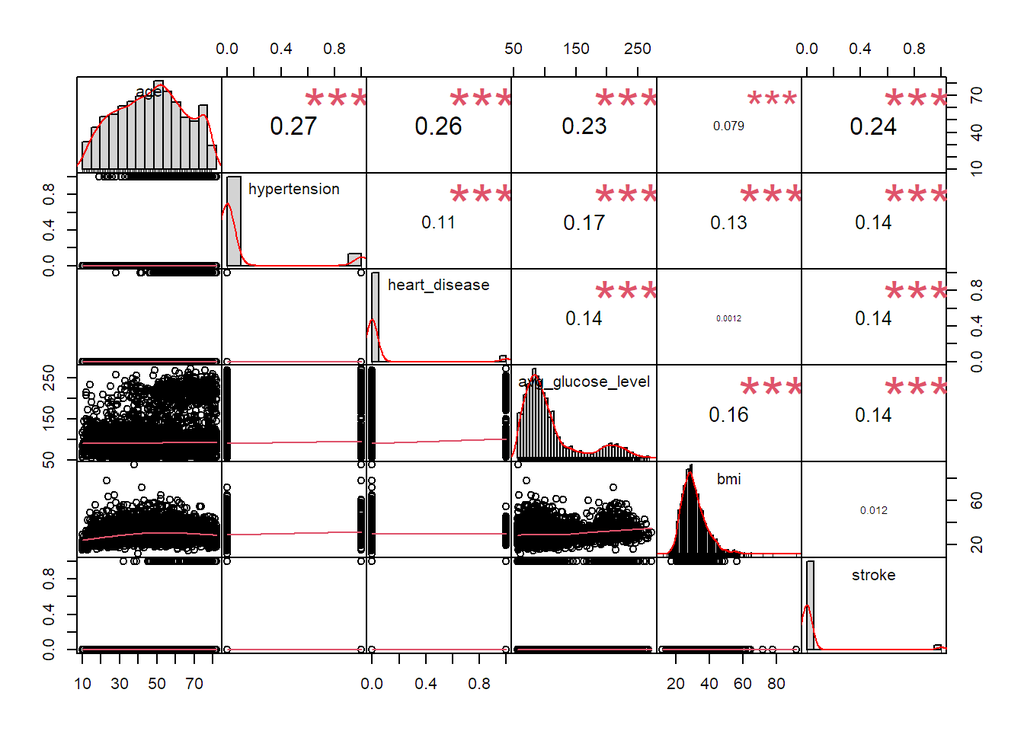

The matrix above are scatter plots and correlations showing the relationship between all the variables. According to the matrix above, all of our variables, except $BMI$, has weak positive relationship with each other as their strength with the dependent variable $Stroke$ are between 0.1 and 0.3. This mean that there will be no multicollinearity problem among the predictors such as $Age$, $Hypertension$, $AVGGlucose$, and $HeartDisease$ when performing regression. However, since $BMI$ seems to have weak relationship with $AVGGlucose$ and$hypertension$, $bmi$ might have an indirect effect to predicting $Stroke$. Thus, all of them except $BMI$ can be used to predict $Stroke$ for regression and further analysis are required to check for indirect effect of $BMI$ against $Stroke$.

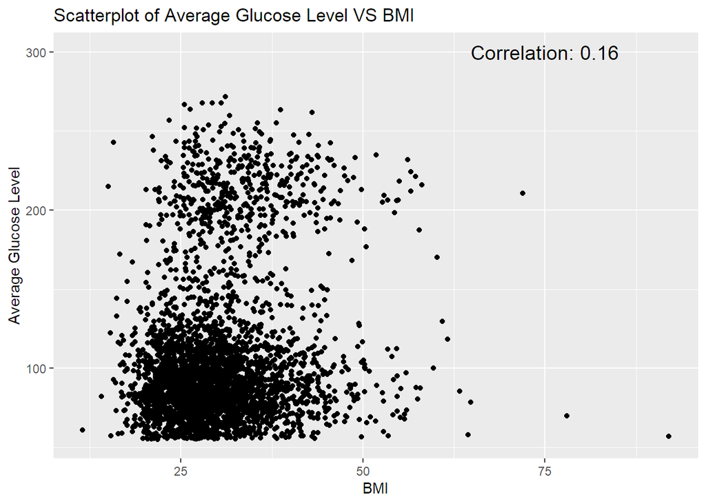

An individual scatterplot of $BMI$ on $AVGGlucose$ is plotted to get a better view. There seems to be extremely weak positive linear relationship between the two variables since their correlation is between 0.1 and 0.3.

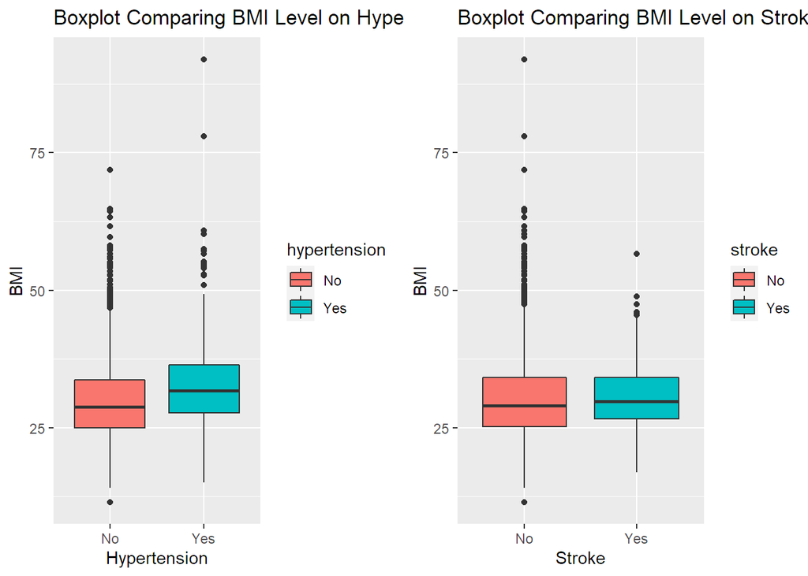

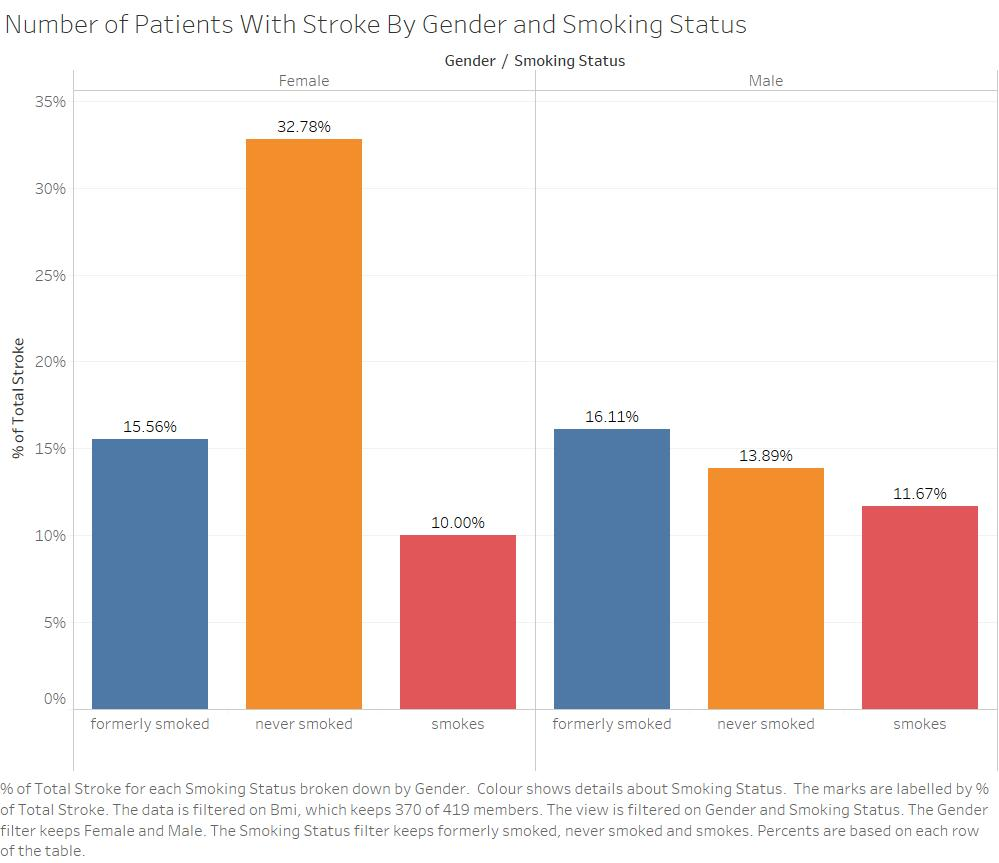